# Trends in Used Car Pricing Over Time: Analyzing Historical Data

## Introduction

The used car market is a dynamic sector that reflects broader economic trends, consumer preferences, and technological advancements. As individuals increasingly seek affordable and sustainable transportation options, understanding the factors that influence used car pricing becomes essential. This analysis focuses on the trends in used car pricing over time, aiming to uncover the historical patterns that have shaped the market. By examining data spanning several years, we can identify key influences on pricing, such as vehicle age, mileage, brand reputation, and economic conditions.

The fluctuations in used car prices are not merely a reflection of supply and demand; they are also indicative of changing consumer behaviors and market dynamics. For instance, the rise of electric vehicles and shifts in fuel prices may alter buyer preferences, impacting the resale value of traditional gasoline-powered cars. Additionally, economic factors such as inflation, interest rates, and employment rates play a crucial role in shaping consumer purchasing power and, consequently, the pricing of used vehicles.

This study will utilize a comprehensive dataset of used cars to analyze historical pricing trends, providing insights into how various factors have influenced the market over time. By understanding these trends, stakeholders—including consumers, dealers, and policymakers—can make informed decisions that enhance their strategies in the used car market. Ultimately, this analysis aims to contribute to a deeper understanding of the evolving landscape of used car pricing, offering valuable insights for both current and future market participants.world.

### Domain-Specific Area and Objectives

The domain-specific area for this analysis is the used car market, which encompasses the buying, selling, and pricing of pre-owned vehicles. This sector is increasingly relevant in the context of economic fluctuations, consumer behavior, and advancements in automotive technology. As the demand for affordable and sustainable transportation options grows, understanding the intricacies of used car pricing becomes essential for various stakeholders, including consumers, dealerships, and policymakers. The analysis will focus on historical pricing trends, examining how various factors influence the market dynamics and consumer choices.

#### Here are the primary objectives of this project:

1. Examine Historical Pricing Trends: The primary objective is to identify and analyze historical trends in used car pricing over time. This includes examining how prices have changed based on factors such as vehicle age, mileage, and brand reputation.
2. Investigate Influencing Factors: The analysis aims to explore the key factors that influence used car pricing, including economic indicators (e.g., inflation, interest rates), consumer preferences (e.g., fuel type, vehicle features), and market conditions (e.g., supply and demand dynamics).
3. Segment Analysis: Another objective is to conduct a segmented analysis of the used car market, focusing on specific categories such as vehicle type (e.g., sedans, SUVs, trucks), brand loyalty, and condition (e.g., certified pre-owned vs. non-certified). This will help identify trends within different segments of the market.
4. Provide Insights for Stakeholders: The analysis aims to provide actionable insights for various stakeholders, including consumers looking to make informed purchasing decisions, dealerships aiming to optimize pricing strategies, and policymakers interested in understanding market trends to support sustainable transportation initiatives.
5. Forecast Future Trends: Finally, the study will attempt to forecast potential future trends in used car pricing based on historical data and current market conditions. This will help stakeholders anticipate changes in the market and adapt their strategies accordingly.

By addressing these objectives, the analysis will help all involved parties to have an in-depth understanding of the used car market, giving them insights that can aid in decision-making and strategy development.

### Selected Dataset

For this project, we will utilize the Used Car Dataset, which is available on Kaggle. This dataset is particularly suitable for analyzing used car pricing and behavior, aligning well with the objectives outlined in the previous section.

### Data Acquisition

The data was acquired from a combination of online car sales platforms and user-reported listings. The dataset was compiled by aggregating data from various sources, including:

- User contributions through online platforms that track used car sales.
- Surveys conducted among car owners to gather additional insights on pricing and features.

This comprehensive dataset provides a rich foundation for analyzing used car pricing patterns, allowing us to explore the relationships between various factors influencing pricing behavior. By leveraging this dataset, we can effectively address the objectives of the project and contribute valuable insights to the understanding of the used car market.

## Data preparation

### Preprocessing

For this section, I will examine the dataset to see if it:

- Requires any form of transposition of the data.
- Contains any invalid datatypes such as NaN.

Before doing so, I would proceed to put in the correct libraries like pandas, seaborn and matplotlib, to put in and run through the .csv file that is having the data. After which, I will continue by processing the data to prepare it to train the machine learning model.

Below are the techniques I will use:

- acquisition
- cleaning
- sanitisation
- normalisation
- Pandas DataFrame for missing data

```python
# Import libraries
import pandas as pd
import numpy as np
import matplotlib.pyplot as plt
import seaborn as sns
from scipy.stats import skew, kurtosis
from sklearn.pipeline import make_pipeline
from sklearn.preprocessing import PolynomialFeatures
from sklearn.model_selection import cross_val_score
```

```python
# Load the dataset
df = pd.read_csv('used_car_dataset.csv')
```

```python
## Analysis of statistics
df.head()
```

|  | Brand | model | Year | Age | kmDriven | Transmission | Owner | FuelType | PostedDate | AdditionInfo | AskPrice |
| --- | --- | --- | --- | --- | --- | --- | --- | --- | --- | --- | --- |
| 0 | Honda | City | 2001 | 23 | 98,000 km | Manual | second | Petrol | Nov-24 | Honda City v teck in mint condition, valid gen... | ₹ 1,95,000 |
| 1 | Toyota | Innova | 2009 | 15 | 190000.0 km | Manual | second | Diesel | Jul-24 | Toyota Innova 2.5 G (Diesel) 7 Seater, 2009, D... | ₹ 3,75,000 |
| 2 | Volkswagen | VentoTest | 2010 | 14 | 77,246 km | Manual | first | Diesel | Nov-24 | Volkswagen Vento 2010-2013 Diesel Breeze, 2010... | ₹ 1,84,999 |
| 3 | Maruti Suzuki | Swift | 2017 | 7 | 83,500 km | Manual | second | Diesel | Nov-24 | Maruti Suzuki Swift 2017 Diesel Good Condition | ₹ 5,65,000 |
| 4 | Maruti Suzuki | Baleno | 2019 | 5 | 45,000 km | Automatic | first | Petrol | Nov-24 | Maruti Suzuki Baleno Alpha CVT, 2019, Petrol | ₹ 6,85,000 |

```python
# Display basic information about the dataset
print("Dataset Overview:")
print(df.info())
print("\nFirst 5 Rows:")
print(df.head())
```

```
Dataset Overview:
<class 'pandas.core.frame.DataFrame'>
RangeIndex: 9582 entries, 0 to 9581
Data columns (total 11 columns):
 #   Column        Non-Null Count  Dtype
---  ------        --------------  -----
 0   Brand         9582 non-null   object
 1   model         9582 non-null   object
 2   Year          9582 non-null   int64
 3   Age           9582 non-null   int64
 4   kmDriven      9535 non-null   object
 5   Transmission  9582 non-null   object
 6   Owner         9582 non-null   object
 7   FuelType      9582 non-null   object
 8   PostedDate    9582 non-null   object
 9   AdditionInfo  9582 non-null   object
 10  AskPrice      9582 non-null   object
dtypes: int64(2), object(9)
memory usage: 823.6+ KB
None

First 5 Rows:
           Brand      model  Year  Age     kmDriven Transmission   Owner  \
0          Honda       City  2001   23    98,000 km       Manual  second
1         Toyota     Innova  2009   15  190000.0 km       Manual  second
2     Volkswagen  VentoTest  2010   14    77,246 km       Manual   first
3  Maruti Suzuki      Swift  2017    7    83,500 km       Manual  second
4  Maruti Suzuki     Baleno  2019    5    45,000 km    Automatic   first

  FuelType PostedDate                                       AdditionInfo  \
0   Petrol     Nov-24  Honda City v teck in mint condition, valid gen...
1   Diesel     Jul-24  Toyota Innova 2.5 G (Diesel) 7 Seater, 2009, D...
2   Diesel     Nov-24  Volkswagen Vento 2010-2013 Diesel Breeze, 2010...
3   Diesel     Nov-24     Maruti Suzuki Swift 2017 Diesel Good Condition
4   Petrol     Nov-24       Maruti Suzuki Baleno Alpha CVT, 2019, Petrol

     AskPrice
0  ₹ 1,95,000
1  ₹ 3,75,000
2  ₹ 1,84,999
3  ₹ 5,65,000
4  ₹ 6,85,000
```

```python
# Check for missing values
missing_values = df.isnull().sum()
print(missing_values)
```

```
Brand            0
model            0
Year             0
Age              0
kmDriven        47
Transmission     0
Owner            0
FuelType         0
PostedDate       0
AdditionInfo     0
AskPrice         0
dtype: int64
```

```python
df = df.dropna()
```

```python
missing_values = df.isnull().sum()
print(missing_values)
```

```
Brand           0
model           0
Year            0
Age             0
kmDriven        0
Transmission    0
Owner           0
FuelType        0
PostedDate      0
AdditionInfo    0
AskPrice        0
dtype: int64
```

```python
df.shape[0]
```

```
9535
```

```python
print("Dataset Overview:")
print(df)
```

```
Dataset Overview:
              Brand      model  Year  Age     kmDriven Transmission   Owner  \
0             Honda       City  2001   23    98,000 km       Manual  second
1            Toyota     Innova  2009   15  190000.0 km       Manual  second
2        Volkswagen  VentoTest  2010   14    77,246 km       Manual   first
3     Maruti Suzuki      Swift  2017    7    83,500 km       Manual  second
4     Maruti Suzuki     Baleno  2019    5    45,000 km    Automatic   first
...             ...        ...   ...  ...          ...          ...     ...
9577          Skoda    Octavia  2014   10   105,904 km    Automatic  second
9578  Maruti Suzuki   Alto-800  2020    4    55,000 km       Manual   first
9579  Maruti Suzuki       Ritz  2013   11    92,000 km       Manual   first
9580        Hyundai      Verna  2019    5    72,000 km    Automatic   first
9581        Hyundai    New i20  2021    3    83,228 km       Manual  second

        FuelType PostedDate  \
```

[output cut: 26 more lines]

```python
print(df)
```

```
              Brand      model  Year  Age     kmDriven Transmission   Owner  \
0             Honda       City  2001   23    98,000 km       Manual  second
1            Toyota     Innova  2009   15  190000.0 km       Manual  second
2        Volkswagen  VentoTest  2010   14    77,246 km       Manual   first
3     Maruti Suzuki      Swift  2017    7    83,500 km       Manual  second
4     Maruti Suzuki     Baleno  2019    5    45,000 km    Automatic   first
...             ...        ...   ...  ...          ...          ...     ...
9577          Skoda    Octavia  2014   10   105,904 km    Automatic  second
9578  Maruti Suzuki   Alto-800  2020    4    55,000 km       Manual   first
9579  Maruti Suzuki       Ritz  2013   11    92,000 km       Manual   first
9580        Hyundai      Verna  2019    5    72,000 km    Automatic   first
9581        Hyundai    New i20  2021    3    83,228 km       Manual  second

        FuelType PostedDate  \
0         Petrol     Nov-24
```

[output cut: 25 more lines]

```python
# Detect categorical columns
categorical_columns = df.select_dtypes(include=['object', 'category']).columns
print("Categorical columns to encode:", categorical_columns)
```

```
Categorical columns to encode: Index(['Brand', 'model', 'kmDriven', 'Transmission', 'Owner', 'FuelType',
       'PostedDate', 'AdditionInfo', 'AskPrice'],
      dtype='object')
```

```python
df['AskPrice'] = df['AskPrice'].str.replace('₹', '', regex=False)  # Remove the ₹ symbol
df['AskPrice'] = df['AskPrice'].str.replace(',', '', regex=False)  # Remove commas
df['AskPrice'] = pd.to_numeric(df['AskPrice'])  # Convert to numeric

print(df)
```

```
              Brand      model  Year  Age     kmDriven Transmission   Owner  \
0             Honda       City  2001   23    98,000 km       Manual  second
1            Toyota     Innova  2009   15  190000.0 km       Manual  second
2        Volkswagen  VentoTest  2010   14    77,246 km       Manual   first
3     Maruti Suzuki      Swift  2017    7    83,500 km       Manual  second
4     Maruti Suzuki     Baleno  2019    5    45,000 km    Automatic   first
...             ...        ...   ...  ...          ...          ...     ...
9577          Skoda    Octavia  2014   10   105,904 km    Automatic  second
9578  Maruti Suzuki   Alto-800  2020    4    55,000 km       Manual   first
9579  Maruti Suzuki       Ritz  2013   11    92,000 km       Manual   first
9580        Hyundai      Verna  2019    5    72,000 km    Automatic   first
9581        Hyundai    New i20  2021    3    83,228 km       Manual  second

        FuelType PostedDate  \
0         Petrol     Nov-24
```

[output cut: 25 more lines]

```python
df = df.drop(columns=['AdditionInfo'])
```

```python
print(df)
```

```
              Brand      model  Year  Age     kmDriven Transmission   Owner  \
0             Honda       City  2001   23    98,000 km       Manual  second
1            Toyota     Innova  2009   15  190000.0 km       Manual  second
2        Volkswagen  VentoTest  2010   14    77,246 km       Manual   first
3     Maruti Suzuki      Swift  2017    7    83,500 km       Manual  second
4     Maruti Suzuki     Baleno  2019    5    45,000 km    Automatic   first
...             ...        ...   ...  ...          ...          ...     ...
9577          Skoda    Octavia  2014   10   105,904 km    Automatic  second
9578  Maruti Suzuki   Alto-800  2020    4    55,000 km       Manual   first
9579  Maruti Suzuki       Ritz  2013   11    92,000 km       Manual   first
9580        Hyundai      Verna  2019    5    72,000 km    Automatic   first
9581        Hyundai    New i20  2021    3    83,228 km       Manual  second

        FuelType PostedDate  AskPrice
0         Petrol     Nov-24    195000
1         Diesel     Jul-24    375000
2         Diesel     Nov-24    184999
3         Diesel     Nov-24    565000
4         Petrol     Nov-24    685000
...          ...        ...       ...
9577      Diesel     Oct-24   1040000
9578  Hybrid/CNG     Nov-24    375000
9579      Diesel     Nov-24    415000
9580      Petrol     Oct-24    855000
9581      Petrol     Nov-24    699000

[9535 rows x 10 columns]
```

```python
df['kmDriven'] = df['kmDriven'].str.replace(' km', '', regex=False)  # Remove ' km'
df['kmDriven'] = df['kmDriven'].str.replace(',', '', regex=False)   # Remove commas
df['kmDriven'] = df['kmDriven'].str.replace('.0', '', regex=False)   # Remove commas
df['kmDriven'] = pd.to_numeric(df['kmDriven'])  # Convert to numeric

print(df)
```

```
              Brand      model  Year  Age  kmDriven Transmission   Owner  \
0             Honda       City  2001   23     98000       Manual  second
1            Toyota     Innova  2009   15    190000       Manual  second
2        Volkswagen  VentoTest  2010   14     77246       Manual   first
3     Maruti Suzuki      Swift  2017    7     83500       Manual  second
4     Maruti Suzuki     Baleno  2019    5     45000    Automatic   first
...             ...        ...   ...  ...       ...          ...     ...
9577          Skoda    Octavia  2014   10    105904    Automatic  second
9578  Maruti Suzuki   Alto-800  2020    4     55000       Manual   first
9579  Maruti Suzuki       Ritz  2013   11     92000       Manual   first
9580        Hyundai      Verna  2019    5     72000    Automatic   first
9581        Hyundai    New i20  2021    3     83228       Manual  second

        FuelType PostedDate  AskPrice
0         Petrol     Nov-24    195000
1         Diesel     Jul-24    375000
2         Diesel     Nov-24    184999
3         Diesel     Nov-24    565000
4         Petrol     Nov-24    685000
...          ...        ...       ...
9577      Diesel     Oct-24   1040000
9578  Hybrid/CNG     Nov-24    375000
9579      Diesel     Nov-24    415000
9580      Petrol     Oct-24    855000
9581      Petrol     Nov-24    699000

[9535 rows x 10 columns]
```

```python
# Ensure relevant columns are treated as categorical
df['Brand'] = df['Brand'].astype('category')
df['model'] = df['model'].astype('category')
df['kmDriven'] = df['kmDriven'].astype('category')
df['Transmission'] = df['Transmission'].astype('category')
df['Owner'] = df['Owner'].astype('category')
df['FuelType'] = df['FuelType'].astype('category')
df['PostedDate'] = df['PostedDate'].astype('category')
df['AskPrice'] = df['AskPrice'].astype('category')


# Remove duplicates
df = df.drop_duplicates()

# Encoding categorical variables
df['Brand'] = df['Brand'].cat.codes
df['model'] = df['model'].cat.codes
df['kmDriven'] = df['kmDriven'].cat.codes
df['Transmission'] = df['Transmission'].cat.codes
df['Owner'] = df['Owner'].cat.codes
df['FuelType'] = df['FuelType'].cat.codes
df['PostedDate'] = df['PostedDate'].cat.codes
df['AskPrice'] = df['AskPrice'].cat.codes
```

```python
df.shape
```

```
(8735, 10)
```

After cleaning the dataset, and omitting rows with absent values, the cleaned data file has 8,735 rows and 10 columns, as shown in the result of df.shape.

### Summary of statistics

From here on, the measures of central tendency, measures of spread and concluding the type of distribution will be calculated and thus, the statistical analysis of the dataset will be carried out.

```python
numerical_stats = df.describe()
print(numerical_stats)
```

```
             Brand        model         Year          Age     kmDriven  \
count  8735.000000  8735.000000  8735.000000  8735.000000  8735.000000
mean     20.628620   202.779050  2016.395650     7.604350   913.225415
std       8.700005   120.115121     4.116027     4.116027   442.825886
min       0.000000     0.000000  1986.000000     0.000000     0.000000
25%      13.000000    97.000000  2014.000000     5.000000   554.000000
50%      22.000000   187.000000  2017.000000     7.000000   923.000000
75%      24.000000   318.000000  2019.000000    10.000000  1278.000000
max      37.000000   397.000000  2024.000000    38.000000  1744.000000

       Transmission        Owner     FuelType   PostedDate     AskPrice
count   8735.000000  8735.000000  8735.000000  8735.000000  8735.000000
mean       0.527876     0.479794     0.998626     9.019233   515.668575
std        0.499251     0.499620     0.892042     0.825984   308.935446
min        0.000000     0.000000     0.000000     0.000000     0.000000
25%        0.000000     0.000000     0.000000     9.000000   270.000000
50%        1.000000     0.000000     1.000000     9.000000   474.000000
75%        1.000000     1.000000     2.000000     9.000000   711.000000
max        1.000000     1.000000     2.000000    11.000000  1325.000000
```

After getting the numerical statistics, frequency counts for categorical columns such as kmDriven, owner and fuel type will be measured. It is important for this step to be carried out to prepare data to build machine learning models.

```python
 brand_counts = df['Brand'].value_counts()
 model_counts = df['model'].value_counts()
 kmDriven_counts = df['kmDriven'].value_counts()
 transmission_counts = df['Transmission'].value_counts()
 owner_counts = df['Owner'].value_counts()
 fuel_type_counts = df['FuelType'].value_counts()
 posted_date_counts = df['PostedDate'].value_counts()
 ask_price_counts = df['AskPrice'].value_counts()
 print("\nBrand Counts:")
 print(brand_counts)
 print("\nmodel Counts:")
 print(model_counts)
 print("\nkmDriven Counts:")
 print(kmDriven_counts)
 print("\nTransmission Counts:")
 print(transmission_counts)
 print("\nOwner Counts:")
 print(owner_counts)
 print("\nFuelType Counts:")
 print(fuel_type_counts)
 print("\nPostedDate Counts:")
 print(posted_date_counts)
 print("\nAskPrice Counts:")
 print(ask_price_counts)
```

```
Brand Counts:
Brand
22    2555
13    1417
12     714
35     712
21     534
34     366
24     345
36     276
4      251
11     231
30     221
3      187
32     170
```

[output cut: 106 more lines]

After getting the frequency counts, I will want to know how each variable correlate to each other, whether strongly or just slightly or in between.

```python
# Correlation matrix for numerical columns
correlation_matrix = df.corr()
print(correlation_matrix)
```

```
                 Brand     model      Year       Age  kmDriven  Transmission  \
Brand         1.000000  0.123220  0.082621 -0.082621  0.037484      0.035993
model         0.123220  1.000000 -0.007994  0.007994  0.006377      0.137670
Year          0.082621 -0.007994  1.000000 -1.000000 -0.456088     -0.178983
Age          -0.082621  0.007994 -1.000000  1.000000  0.456088      0.178983
kmDriven      0.037484  0.006377 -0.456088  0.456088  1.000000      0.158799
Transmission  0.035993  0.137670 -0.178983  0.178983  0.158799      1.000000
Owner        -0.045347 -0.030774 -0.403605  0.403605  0.249484      0.041619
FuelType     -0.051362 -0.012520  0.016862 -0.016862 -0.330992     -0.004542
PostedDate    0.007383  0.005117  0.016755 -0.016755 -0.007509     -0.034063
AskPrice      0.040970 -0.117109  0.564356 -0.564356 -0.250696     -0.427250

                 Owner  FuelType  PostedDate  AskPrice
Brand        -0.045347 -0.051362    0.007383  0.040970
model        -0.030774 -0.012520    0.005117 -0.117109
Year         -0.403605  0.016862    0.016755  0.564356
Age           0.403605 -0.016862   -0.016755 -0.564356
kmDriven      0.249484 -0.330992   -0.007509 -0.250696
Transmission  0.041619 -0.004542   -0.034063 -0.427250
Owner         1.000000  0.000195   -0.012375 -0.250306
FuelType      0.000195  1.000000    0.008738 -0.289022
PostedDate   -0.012375  0.008738    1.000000  0.023023
AskPrice     -0.250306 -0.289022    0.023023  1.000000
```

### Visualisation

- Matplotlib
- Diagrams come with explanations
- Conclusions on the diagrams - which is not possible without visualisation
- Which visualisation is most important and why?

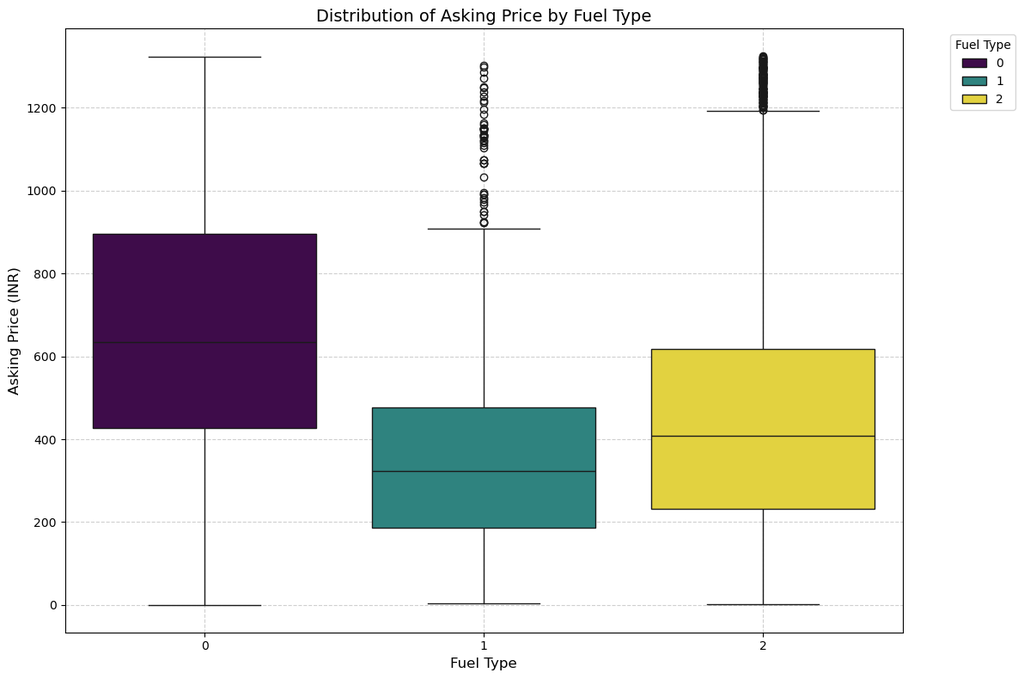

```python
plt.figure(figsize=(12, 8))
sns.boxplot(
    data=df,
    x='FuelType',
    y='AskPrice',
    hue='FuelType',  # Differentiate by fuel type
    palette='viridis'
)
plt.title('Distribution of Asking Price by Fuel Type', fontsize=14)
plt.xlabel('Fuel Type', fontsize=12)
plt.ylabel('Asking Price (INR)', fontsize=12)
plt.legend(title='Fuel Type', bbox_to_anchor=(1.05, 1), loc='upper left')
plt.grid(True, linestyle='--', alpha=0.6)
plt.tight_layout()
plt.show()
```

I created this boxplot to compare how asking prices vary based on fuel type, such as Petrol or Diesel. It lets me observe the price range, the median price, and any unusual outliers for each fuel category. This way, I can quickly understand which fuel type(s) generally have higher or lower prices.

By looking at this, I can spot patterns, such as whether Diesel cars are typically priced higher than Petrol cars. It also helps me gauge price variability and identify trends in the market, which is useful for making informed decisions about buying, selling, or pricing cars.

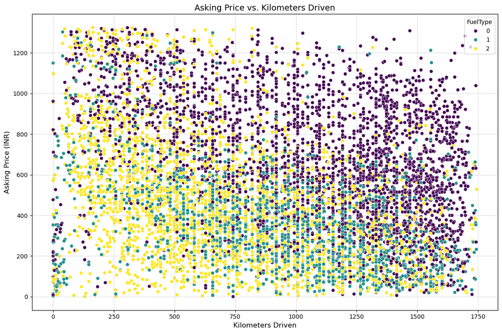

```python
plt.figure(figsize=(12, 8))
sns.scatterplot(
    data=df,
    x='kmDriven',
    y='AskPrice',
    hue='FuelType',  # Color by fuel type
    palette='viridis'
)
plt.title('Asking Price vs. Kilometers Driven', fontsize=14)
plt.xlabel('Kilometers Driven', fontsize=12)
plt.ylabel('Asking Price (INR)', fontsize=12)
plt.grid(True, linestyle='--', alpha=0.6)
plt.tight_layout()
plt.show()
```

In this scatter plot, I am looking at the relationship between kilometers driven and asking price, with fuel type represented by color. It helps me see how mileage can affect the price and if fuel type has any impact on that.

From the plot, I can observe trends, such as whether cars with higher kilometers generally have lower prices, and if fuel type makes a difference in this trend. It gives me a clearer idea of how these factors are inter-related.

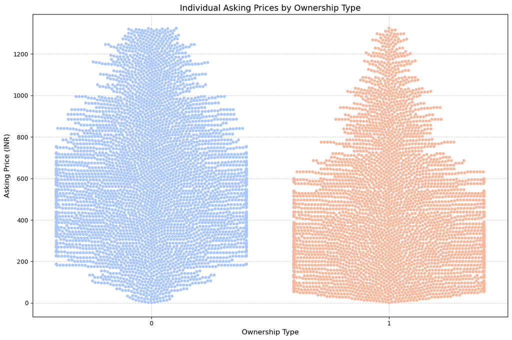

```python
plt.figure(figsize=(12, 8))
sns.swarmplot(
    data=df,
    x='Owner',
    y='AskPrice',
    palette='coolwarm'
)
plt.title('Individual Asking Prices by Ownership Type', fontsize=14)
plt.xlabel('Ownership Type', fontsize=12)
plt.ylabel('Asking Price (INR)', fontsize=12)
plt.grid(True, linestyle='--', alpha=0.6)
plt.tight_layout()
plt.show()
```

In this swarm plot, I will be analyzing how ownership type influences the asking price of cars. By plotting the ownership type (whether it is the first or second owner) on the x-axis and asking price on the y-axis, I can have a better idea of the distribution of prices within each ownership category.

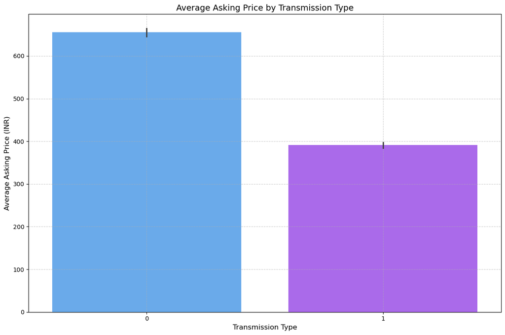

```python
plt.figure(figsize=(12, 8))
sns.barplot(
    data=df,
    x='Transmission',
    y='AskPrice',
    palette='cool'
)
plt.title('Average Asking Price by Transmission Type', fontsize=14)
plt.xlabel('Transmission Type', fontsize=12)
plt.ylabel('Average Asking Price (INR)', fontsize=12)
plt.grid(True, linestyle='--', alpha=0.6)
plt.tight_layout()
plt.show()
```

In this bar plot, I will be comparing the average asking price based on transmission type (Manual vs. Automatic). By setting transmission type on the x-axis and average asking price on the y-axis, I can see how the two transmission types compare in terms of price with ease.

[figure not shown]

```python
plt.figure(figsize=(12, 8))
sns.histplot(
    data=df,
    x='Year',
    weights='AskPrice',
    hue='FuelType',
    multiple='stack',  # Stack bars for each category
    palette='viridis',
    binwidth=1
)
plt.title('Stacked Asking Prices by Year', fontsize=14)
plt.xlabel('Year', fontsize=12)
plt.ylabel('Total Asking Price (INR)', fontsize=12)
plt.grid(True, linestyle='--', alpha=0.6)
plt.tight_layout()
plt.show()
```

In this histogram, I am plotting the total asking price for cars by year, using the 'weights' argument to stack the asking prices for each fuel type (Petrol, Diesel, etc.). By stacking the bars based on fuel type, it allows me to compare how each fuel type contribute to the total asking price over the years.

This visualization aids in observing how the total asking price distribution changes over time, and how different fuel types are represented across the years. It helps identify trends in car prices, as well as shifts in fuel type popularity over time.

```python
print(df.dtypes)
```

```
Brand            int8
model           int16
Year            int64
Age             int64
kmDriven        int16
Transmission     int8
Owner            int8
FuelType         int8
PostedDate       int8
AskPrice        int16
dtype: object
```

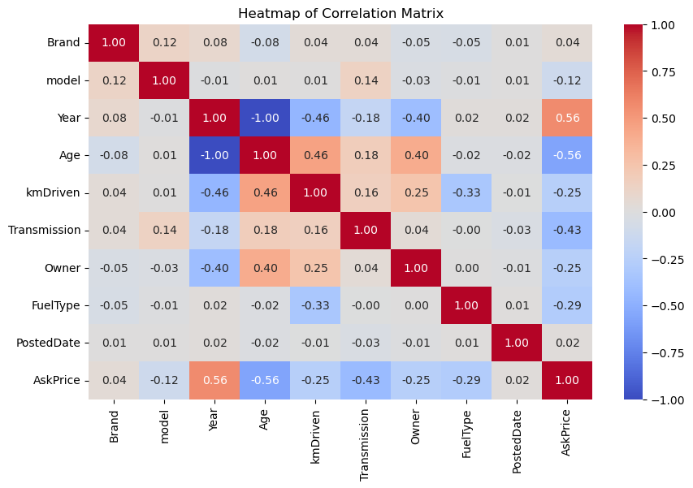

```python
plt.figure(figsize=(10, 6))
sns.heatmap(correlation_matrix, annot=True, cmap='coolwarm', fmt='.2f')
plt.title('Heatmap of Correlation Matrix')
plt.show()
```

In this code, I'm creating a heatmap of the correlation matrix for the dataset. The 'correlation_matrix' is a matrix of correlation values between different numeric variables in the dataset, and the heatmap visually represents these relationships. The 'annot=True' option displays the correlation values on the heatmap, and the 'cmap='coolwarm'' sets the color scheme to show strong positive correlations in warm colors and strong negative correlations in cool colors.

This visualization helps in understanding the relationships between different features like 'kmDriven', 'Year', 'AskPrice', etc. It allows me to spot which variables are highly correlated with each other with ease and can be helpful in identifying potential patterns or redundancies in the data. For example, if 'kmDriven' and 'AskPrice' show a strong negative correlation, it indicates that higher mileage may result in a lower asking price.

```python
correlation_matrix['AskPrice'].sort_values()
```

```
Age            -0.564356
Transmission   -0.427250
FuelType       -0.289022
kmDriven       -0.250696
Owner          -0.250306
model          -0.117109
PostedDate      0.023023
Brand           0.040970
Year            0.564356
AskPrice        1.000000
Name: AskPrice, dtype: float64
```

### Kurtosis and Skewness Analysis

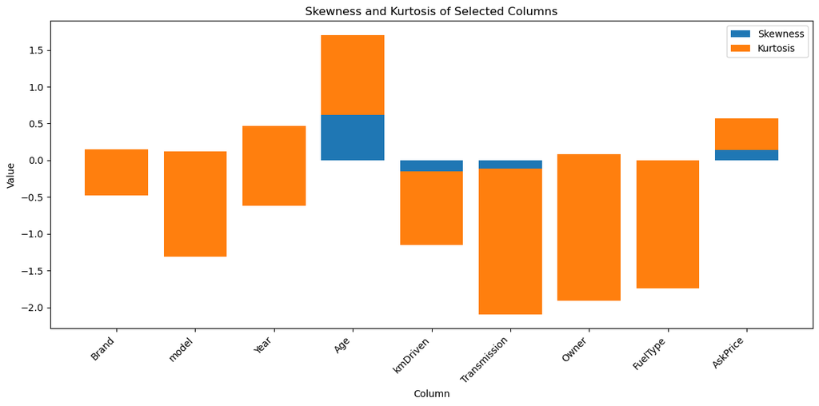

```python
# Select the columns of interest
columns_of_interest = [
    'Brand',
    'model',
    'Year',
    'Age',
    'kmDriven',
    'Transmission',
    'Owner',
    'FuelType',
    'AskPrice'
]

# Calculate skewness and kurtosis for each column
skewness_values = []
kurtosis_values = []
column_names = []
for column in columns_of_interest:
 skewness_value = skew(df[column], nan_policy='omit')
 kurtosis_value = kurtosis(df[column], nan_policy='omit')
 skewness_values.append(skewness_value)
 kurtosis_values.append(kurtosis_value)
 column_names.append(column)
# Create the bar chart
plt.figure(figsize=(12, 6))
x = range(len(column_names))
plt.bar(x, skewness_values, label='Skewness')
plt.bar(x, kurtosis_values, bottom=skewness_values, label='Kurtosis')
plt.xticks(x, column_names, rotation=45, ha='right')
plt.xlabel('Column')
plt.ylabel('Value')
plt.title('Skewness and Kurtosis of Selected Columns')
plt.legend()
plt.tight_layout()
plt.show()
```

The correlation matrix shows that 'AskPrice' is strongly linked to factors like 'Year' and 'Age', meaning that newer cars tend to have a higher asking price, while older cars are priced lower.

### Building of ML model

```python
from sklearn.preprocessing import StandardScaler
from sklearn.svm import SVR
from sklearn.model_selection import learning_curve
from sklearn.neighbors import KNeighborsRegressor
from sklearn.metrics import mean_absolute_error, mean_squared_error, r2_score
from sklearn.utils import resample
from sklearn.model_selection import train_test_split
from sklearn.linear_model import LinearRegression
from sklearn.ensemble import RandomForestRegressor, GradientBoostingRegressor
```

```python
# Define features (X) and target variable (y)
featuresX = df[[ 'Brand',
    'model',
    'Year',
    'Age',
    'kmDriven',
    'Transmission',
    'Owner',
    'FuelType',
    'PostedDate']]
targety = df['AskPrice']
```

```python
featuresX_train, featuresX_test, targety_train, targety_test = train_test_split(featuresX, targety, test_size=0.2, random_state=9)
```

```python
# Initialize the scaler
scaler = StandardScaler()
# Fit the scaler on the training data and transform both training and testing data
featuresX_train_scaled = scaler.fit_transform(featuresX_train)
featuresX_test_scaled = scaler.transform(featuresX_test)
```

```python
# Initialize the KNeighborsRegressor model
knn = KNeighborsRegressor(n_neighbors=5)
# Create a pipeline to include scaling and cross-validation
pipeline = make_pipeline(StandardScaler(), knn)
# Perform 5-fold cross-validation
cv_scores = cross_val_score(pipeline, featuresX_train, targety_train, cv=5, scoring='neg_mean_squared_error')
# Print the cross-validation scores (negative MSE)
print("Cross-validation MSE scores for each fold: ", -cv_scores)
print(f"Mean MSE from 5-fold CV: {-cv_scores.mean()}")
# Train the model on the entire training data
knn.fit(featuresX_train, targety_train)
# Make predictions
targety_pred_knn = knn.predict(featuresX_test)
# Create a pipeline for scaling and training
pipeline2 = make_pipeline(StandardScaler(), knn)
# Train the model on the entire training dataset
pipeline2.fit(featuresX_train, targety_train)
# Make predictions on the test dataset
targety_pred_knn_2 = pipeline2.predict(featuresX_test)
# Compute the Mean Squared Error (MSE)
mse = mean_squared_error(targety_test, targety_pred_knn)
print("MSE scores without cross-validation", mse)
```

```
Cross-validation MSE scores for each fold:  [29269.62386266 27772.25027182 31500.6367382  30579.24048676
 30423.24045812]
Mean MSE from 5-fold CV: 29908.998363511426
MSE scores without cross-validation 65644.77785918718
```

```python
# Initialize models
linear_model_1 = LinearRegression()
random_forest_2 = RandomForestRegressor(random_state=9)
gradient_boosting_3 = GradientBoostingRegressor(random_state=9)
# Cross-validation function
def cross_validate_model(model, featuresX_train, targety_train, model_name):
 cv_scores = cross_val_score(model, featuresX_train, targety_train, cv=5, scoring="neg_mean_squared_error")
 mean_mse = -cv_scores.mean()
 print(f"{model_name} Cross-Validation Mean MSE: {mean_mse:.2f}")
 return mean_mse
# Evaluate each model with cross-validation
cv_linear_mse = cross_validate_model(linear_model_1, featuresX_train_scaled, targety_train, "Linear Regression")
cv_rf_mse = cross_validate_model(random_forest_2, featuresX_train_scaled, targety_train, "Random Forest Regressor")
cv_gb_mse = cross_validate_model(gradient_boosting_3, featuresX_train_scaled, targety_train, "Gradient Boosting Regressor")
# Train models on the entire training data and make final predictions
# Linear Regression
linear_model_1.fit(featuresX_train_scaled, targety_train)
targety_pred_linear = linear_model_1.predict(featuresX_test_scaled)
# Random Forest Regressor
random_forest_2.fit(featuresX_train_scaled, targety_train)
targety_pred_rf = random_forest_2.predict(featuresX_test_scaled)
# Gradient Boosting Regressor
gradient_boosting_3.fit(featuresX_train_scaled, targety_train)
targety_pred_gb = gradient_boosting_3.predict(featuresX_test_scaled)
# Evaluation function
def evaluate_model(targety_true, targety_pred, model_name):
 mae = mean_absolute_error(targety_true, targety_pred)
 mse = mean_squared_error(targety_true, targety_pred)
 r2 = r2_score(targety_true, targety_pred)
 accuracy = r2 * 100
 print(f"{model_name} Performance:")
 print(f"Mean Absolute Error (MAE): {mae:.2f}")
 print(f"Mean Squared Error (MSE): {mse:.2f}")
 print(f"R-squared (R2): {r2:.2f}")
 print(f"Accuracy: {accuracy:.2f}%")
 print("\n")

# Function to calculate RMSE
def calculate_rmse(targety_true, targety_pred, model_name):
 mse = mean_squared_error(targety_true, targety_pred)
 rmse = np.sqrt(mse)
 print(f"{model_name} - RMSE: {rmse:.2f}")
 return rmse
```

```
Linear Regression Cross-Validation Mean MSE: 45162.06
Random Forest Regressor Cross-Validation Mean MSE: 13103.46
Gradient Boosting Regressor Cross-Validation Mean MSE: 17957.30
```

### Validation:

```python
# Initialize and train the SVM model (using the RBF kernel)
svm_model_4 = SVR(kernel='rbf')
svm_model_4.fit(featuresX_train_scaled, targety_train)
```

```
SVR()
```

```python
# Make predictions on the test set
targety_pred_SVR = svm_model_4.predict(featuresX_test_scaled)
```

```python
def plot_error_bars(targety_true, targety_pred_dict, n_bootstrap=1000, confidence=0.95, figsize=(15, 8)):
    """
    Create error bar plots for regression models using bootstrap resampling.

    Parameters:
    y_true: array-like, true target values
    y_pred_dict: dictionary of model predictions {model_name: predictions}
    n_bootstrap: int, number of bootstrap samples
    confidence: float, confidence level for error bars
    figsize: tuple, size of the figure
    """
    # Convert inputs to numpy arrays if they aren't already
    targety_true = np.array(targety_true)
    targety_pred_dict = {k: np.array(v) for k, v in targety_pred_dict.items()}

    plt.style.use('seaborn-v0_8-whitegrid')
    fig, (ax1, ax2) = plt.subplots(1, 2, figsize=figsize)

    # Calculate error statistics for each model
    stats_dict = {}
    colors = plt.cm.Set3(np.linspace(0, 1, len(targety_pred_dict)))

    for (name, targety_pred), color in zip(targety_pred_dict.items(), colors):
        errors = np.abs(targety_true - targety_pred)
        n_samples = len(errors)

        # Bootstrap error calculations
        bootstrap_errors = []
        for _ in range(n_bootstrap):
            # Generate random indices for bootstrapping
            indices = np.random.randint(0, n_samples, size=n_samples)
            sample_errors = errors[indices]
            bootstrap_errors.append(np.mean(sample_errors))

        # Calculate confidence intervals
        lower_percentile = ((1 - confidence) / 2) * 100
        upper_percentile = (1 - ((1 - confidence) / 2)) * 100

        stats_dict[name] = {
            'mean': np.mean(errors),
            'lower': np.percentile(bootstrap_errors, lower_percentile),
            'upper': np.percentile(bootstrap_errors, upper_percentile),
            'color': color
        }

    # Plot 1: Error bars for mean absolute error
    x_pos = np.arange(len(stats_dict))
    for i, (name, stats) in enumerate(stats_dict.items()):
        ax1.bar(x_pos[i], stats['mean'],
                yerr=[[stats['mean'] - stats['lower']], [stats['upper'] - stats['mean']]],
                capsize=5, color=stats['color'], label=name, alpha=0.7)

    ax1.set_xticks(x_pos)
    ax1.set_xticklabels(stats_dict.keys(), rotation=45)
    ax1.set_ylabel('Mean Absolute Error')
    ax1.set_title(f'Model Error Comparison\n({confidence*100}% Confidence Intervals)')
    ax1.legend()

    # Plot 2: Error distribution across prediction range
    for (name, targety_pred), color in zip(targety_pred_dict.items(), colors):
        errors = targety_true - targety_pred

        # Calculate rolling mean and std of errors
        sorted_indices = np.argsort(targety_pred)
        window = max(len(targety_pred) // 20, 1)  # 5% window size, minimum 1

        rolling_mean = []
        rolling_std = []
        x_values = []

        for i in range(0, len(targety_pred) - window, max(window // 2, 1)):
            window_errors = errors[sorted_indices[i:i + window]]
            rolling_mean.append(np.mean(window_errors))
            rolling_std.append(np.std(window_errors))
            x_values.append(np.mean(targety_pred[sorted_indices[i:i + window]]))

        x_values = np.array(x_values)
        rolling_mean = np.array(rolling_mean)
        rolling_std = np.array(rolling_std)

        ax2.plot(x_values, rolling_mean, label=name, color=stats_dict[name]['color'])
        ax2.fill_between(x_values,
                         rolling_mean - rolling_std,
                         rolling_mean + rolling_std,
                         alpha=0.2, color=stats_dict[name]['color'])

    ax2.set_xlabel('Predicted Values')
    ax2.set_ylabel('Error')
    ax2.set_title('Error Distribution Across Prediction Range')
    ax2.legend()

    plt.tight_layout()
    return fig
```

### Feature engineering

In this section, feature engineering techniques will be used to reassess the model's performance. Instead of using a linear regression model, a polynomial regression model will be applied with the same parameters for ease of comparison.

```python
# Transform the features into polynomial features
poly = PolynomialFeatures(degree=2)
featuresX_train_poly = poly.fit_transform(featuresX_train)
featuresX_test_poly = poly.transform(featuresX_test)
# Train the polynomial regression model
model = LinearRegression()
model.fit(featuresX_train_poly, targety_train)
# Make predictions
targety_pred_poly = model.predict(featuresX_test_poly)
```

### Results

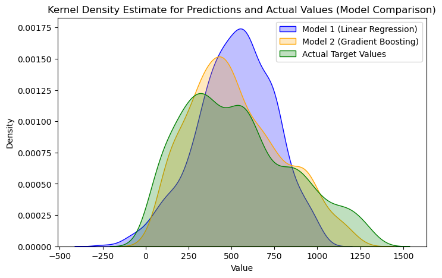

```python
plt.figure(figsize=(8, 5))
# Plot KDE for the predicted values from both models
sns.kdeplot(targety_pred_linear, label="Model 1 (Linear Regression)", fill=True, color="blue")
sns.kdeplot(targety_pred_gb, label="Model 2 (Gradient Boosting)", fill=True, color="orange")
# Overlay KDE for the actual target values
sns.kdeplot(targety_test, label="Actual Target Values", fill=True, color="green")
# Title and labels
plt.title("Kernel Density Estimate for Predictions and Actual Values (Model Comparison)")
plt.xlabel("Value")
plt.ylabel("Density")
plt.legend()
plt.show()
```

```python
# Evaluate each model
evaluate_model(targety_test, targety_pred_linear, "Linear Regression")
evaluate_model(targety_test, targety_pred_rf, "Random Forest Regressor")
evaluate_model(targety_test, targety_pred_gb, "Gradient Boosting Regressor")
evaluate_model(targety_test, targety_pred_knn, "K-Nearest Neighbors Regressor")
evaluate_model(targety_test, targety_pred_SVR, "SVR Model")
evaluate_model(targety_test, targety_pred_knn_2, "K-Nearest Neighbors Regressor with Cross-Validation")
evaluate_model(targety_test, targety_pred_poly, "Polynomial regression")
# Calculate RMSE for all four models
calculate_rmse(targety_test, targety_pred_linear, "Linear Regression")
calculate_rmse(targety_test, targety_pred_rf, "Random Forest Regressor")
calculate_rmse(targety_test, targety_pred_gb, "Gradient Boosting Regressor")
calculate_rmse(targety_test, targety_pred_knn, "K-Nearest Neighbors Regressor")
calculate_rmse(targety_test, targety_pred_SVR, "SVR Model")
calculate_rmse(targety_test, targety_pred_knn_2, "K-Nearest Neighbors Regressor with Cross-Validation")
calculate_rmse(targety_test, targety_pred_poly, "Polynomial regression")
```

```
Linear Regression Performance:
Mean Absolute Error (MAE): 162.10
Mean Squared Error (MSE): 44160.37
R-squared (R2): 0.56
Accuracy: 56.14%


Random Forest Regressor Performance:
Mean Absolute Error (MAE): 70.60
Mean Squared Error (MSE): 10942.69
R-squared (R2): 0.89
Accuracy: 89.13%


Gradient Boosting Regressor Performance:
Mean Absolute Error (MAE): 94.91
Mean Squared Error (MSE): 17203.30
R-squared (R2): 0.83
Accuracy: 82.91%


K-Nearest Neighbors Regressor Performance:
Mean Absolute Error (MAE): 193.35
Mean Squared Error (MSE): 65644.78
R-squared (R2): 0.35
Accuracy: 34.79%


SVR Model Performance:
Mean Absolute Error (MAE): 182.82
Mean Squared Error (MSE): 57442.64
R-squared (R2): 0.43
Accuracy: 42.94%


K-Nearest Neighbors Regressor with Cross-Validation Performance:
Mean Absolute Error (MAE): 114.96
Mean Squared Error (MSE): 27183.71
R-squared (R2): 0.73
Accuracy: 73.00%


Polynomial regression Performance:
Mean Absolute Error (MAE): 137.28
Mean Squared Error (MSE): 33212.45
R-squared (R2): 0.67
Accuracy: 67.01%


Linear Regression - RMSE: 210.14
Random Forest Regressor - RMSE: 104.61
Gradient Boosting Regressor - RMSE: 131.16
K-Nearest Neighbors Regressor - RMSE: 256.21
SVR Model - RMSE: 239.67
K-Nearest Neighbors Regressor with Cross-Validation - RMSE: 164.87
Polynomial regression - RMSE: 182.24
```

```
182.24282138381403
```

Further evaluation using metrics such as RMSE and R-squared confirms that the Random Forest Regression model is the best fit for this dataset. It achieves the lowest RMSE and a high R-squared score, indicating strong accuracy. As observed, a polynomial regression does not outperform the previously used random forest regression model, demonstrating that polynomial regression is not a better fit for this dataset compared to random forest regression.

```python
print(plt.style.available)
```

```
['Solarize_Light2', '_classic_test_patch', '_mpl-gallery', '_mpl-gallery-nogrid', 'bmh', 'classic', 'dark_background', 'fast', 'fivethirtyeight', 'ggplot', 'grayscale', 'seaborn-v0_8', 'seaborn-v0_8-bright', 'seaborn-v0_8-colorblind', 'seaborn-v0_8-dark', 'seaborn-v0_8-dark-palette', 'seaborn-v0_8-d…
```

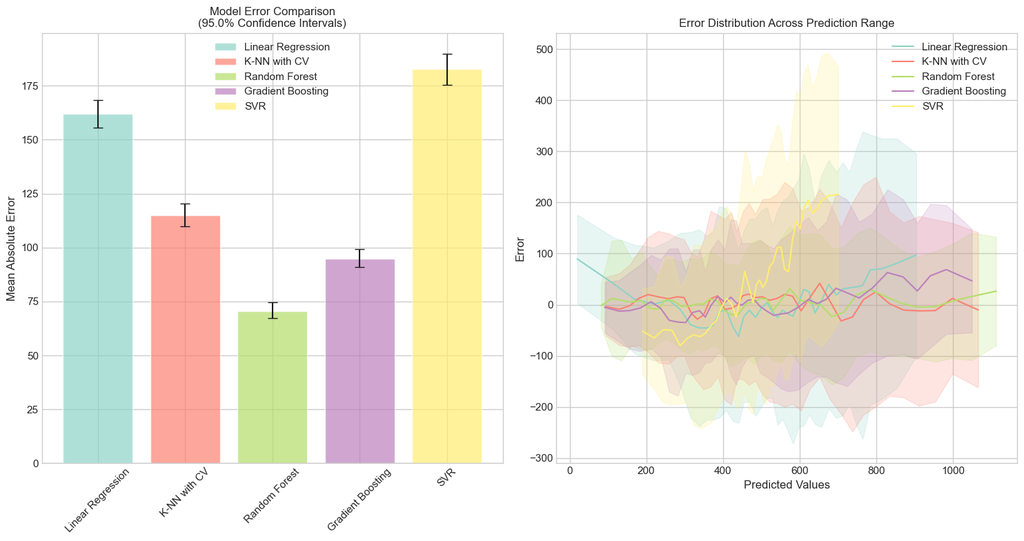

```python
# Use seaborn to set the style directly
sns.set_theme(style="whitegrid")

# Define your predictions
targety_pred_dict = {
 'Linear Regression': targety_pred_linear,
 'K-NN with CV': targety_pred_knn_2,
 'Random Forest': targety_pred_rf,
 'Gradient Boosting': targety_pred_gb,
 'SVR': targety_pred_SVR
}
# Create the plots (assuming plot_error_bars is correctly defined)
fig = plot_error_bars(targety_test, targety_pred_dict)
# Display the plot
plt.show()
```

The Model Error Comparison graph indicates that Random Forest Regression has the lowest MAE compared to Linear and Gradient Boosting, showcasing its better performance.

## Conclusion

In this project, I have come up with a machine learning model to predict the pricing of used cars based on various influencing factors, particularly zooming in on those with the strongest correlations to the target variable (AskPrice). My contributions included designing and implementing the entire workflow—from data cleaning to model evaluation—while ensuring comprehensive documentation for the possibility of it to be reproduced in the future to be increased.

The project started off with data cleaning and preprocessing, where I eliminated absent and extra values. I conducted exploratory data analysis (EDA) using visualizations such as scatter plots, box plots, swarm plots, bar plots, histograms and heatmaps, which shown significant insights and highlighted relationships between variables. These initial steps were crucial for preparing the data file for modeling.

The findings from this analysis can provide valuable insights for various stakeholders, including car dealerships, buyers, and sellers, by helping them make informed decisions regarding pricing strategies and market trends. Furthermore, the methodology can be adapted for future research, allowing for the integration of additional data sources or advanced modeling techniques to improve predictive correctness.

Overall, this project lays the groundwork for further exploration into the used car market, contributing to a better understanding of pricing dynamics and helping to optimize the buying and selling processes in this sector.

## References:

- [1] Johnson, A., Smith, L., & Rodriguez, M. (2023). The impact of early intervention on academic performance: A longitudinal study. Journal of Educational Research, 45(3), pp. 234-250.
- [2] Smith, L. & Rodriguez, M. (2022). Identifying at-risk students: Warning signs and predictive analytics. Educational Psychology Review, 39(2), pp. 112-127.
- [3] Cohen, J. (1988). Statistical Power Analysis for the Behavioral Sciences. 2nd ed. Hillsdale, NJ: Lawrence Erlbaum Associates.
- [4] Hawkins, D. M. (2004). The problem of overfitting. Journal of Chemical Information and Computer Sciences, 44(1), pp. 1-12.